# Predicting Funny Super Bowl Ads

Devesh Dalmia

05/22

# 1 Intro

One of the things Superbowl is known for are the exclusive new ads released in-between the finals during the break. Millions of people tune in every year and there is quite a buzz regarding which company had the best ad/trailer. Companies end up spending millions making these ads, and they’re a hit or miss with the audience.

**So I wanted to explore: Can we predict if a superbowl ad is going to be funny?**

And if not, can we at least look into the factors that make a superbowl ad? Will adding chickens to my Volkswagen commercial increase its buzz and publicity? How funny will my ad be if I include politics? Etc, etc, etc.

To do this, I found a dataset on Kaggle that collected binomial data on superbowl commercials and certain variables. I’ve gone ahead and cleaned up the data beforehand with just relevant columns, and now let’s take a look at what we have.

# 2 EDA: Exploring our dataset

## 2.1 Summarizing our data

```r
head(data)
```

Table 2.1:

| funny | show_product_quickly | patriotic | celebrity | danger | animals |
| --- | --- | --- | --- | --- | --- |
| FALSE | FALSE | FALSE | FALSE | FALSE | FALSE |
| TRUE | TRUE | FALSE | TRUE | TRUE | FALSE |
| TRUE | FALSE | FALSE | FALSE | TRUE | TRUE |
| FALSE | TRUE | FALSE | FALSE | FALSE | FALSE |
| TRUE | TRUE | FALSE | FALSE | TRUE | TRUE |
| TRUE | TRUE | FALSE | TRUE | TRUE | TRUE |

```r
data$funny <- as.factor(data$funny)
data$show_product_quickly <- as.factor(data$show_product_quickly)
data$patriotic <- as.factor(data$patriotic)
data$celebrity <- as.factor(data$celebrity)
data$danger <- as.factor(data$danger)
data$animals <- as.factor(data$animals)

data=na.omit(data)

summary(data)
```

```
   funny     show_product_quickly patriotic   celebrity     danger
 FALSE: 76   FALSE: 78            FALSE:203   FALSE:176   FALSE:169
 TRUE :168   TRUE :166            TRUE : 41   TRUE : 68   TRUE : 75
  animals
 FALSE:155
 TRUE : 89
```

We start off with doing some exploratory analysis on the data which we have. The data in the columns are converted to a factor of either “True” or “False.” In the summary section, we see a rough distribution of how many values for each variable are associated with the following factors. With the code below you can see just how the responses are staggered between the two choices.

## 2.2 Breaking down our data

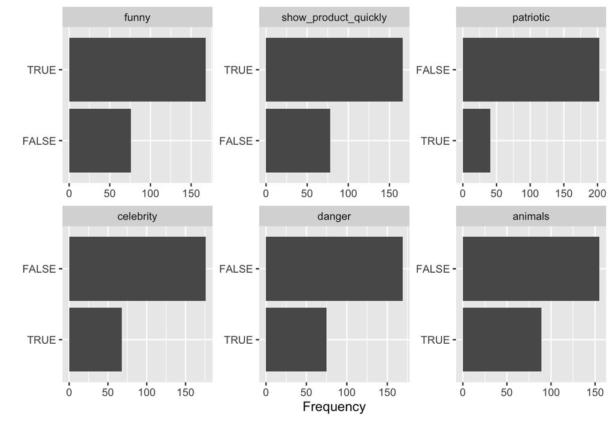

```
Danger (F/T):  0.692623 0.307377
```

```
Funny (F/T):  0.3114754 0.6885246
```

```
Patriotic (F/T):  0.8319672 0.1680328
```

```
Animals (F/T):  0.6352459 0.3647541
```

```
Show Product Quickly (F/T):  0.3196721 0.6803279
```

The above values represent the percentages of responses distributed in decimal form.

## 2.3 Correlation in our data

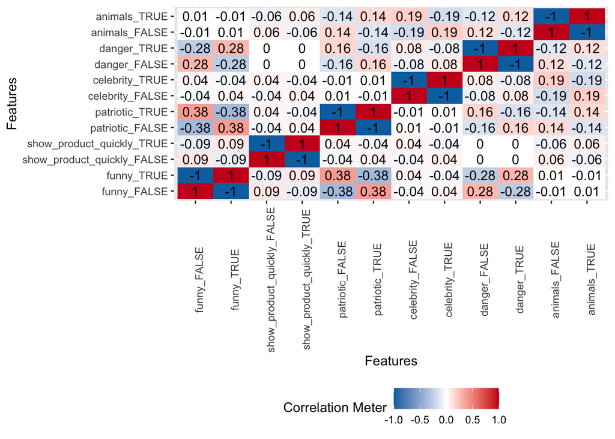

```r
plot_correlation(data, type = 'discrete','funny')
```

Above we have the correlation plot that tells us how each variable is correlated with each other. The values range from -1 to 1, with 0 representing a weak correlation (hence the color white) and -1 and 1 representing strong correlation. We see the strongest correlation between the factors **patriotic** and **funny** with a value of +/-0.38.

# 3 Data Split

The first step in our machine learning process is to split our data so that we have enough datapoints for creating our model, but also for testing our model at the end to check the accuracy. Afterall, we need datapoints to feed into our model see if it makes predictions well.

```r
set.seed(100)
# choosing 75% of the data to be the training data
data_split <- initial_split(data, prop = .75)
# extracting training data and test data as two seperate dataframes
datatrain <- training(data_split)
datatest <- testing(data_split)

summary(datatrain)
```

```
   funny     show_product_quickly patriotic   celebrity     danger
 FALSE: 60   FALSE: 61            FALSE:152   FALSE:135   FALSE:125
 TRUE :123   TRUE :122            TRUE : 31   TRUE : 48   TRUE : 58
  animals
 FALSE:118
 TRUE : 65
```

```r
summary(datatest)
```

```
   funny    show_product_quickly patriotic  celebrity    danger    animals
 FALSE:16   FALSE:17             FALSE:51   FALSE:41   FALSE:44   FALSE:37
 TRUE :45   TRUE :44             TRUE :10   TRUE :20   TRUE :17   TRUE :24
```

The above summary represents how many amount of datapoints have been assigned for training and testing.

# 4 Solo Model Testing

The first model which we are going to create, or rather a series of models, are simple logistic models where we predict our outcome, **funny**, based on just a single factor. We are going to use a loop to replace the variables in the model one-by-one and then after it is created, we will extract values and information and store it in a separate table.

## 4.1 Automating our model

```r
#Log-odds to probability conversion universal function.

logit2prob <- function(logit){
  odds <- exp(logit)
  prob <- odds / (1 + odds)
  return(prob)
}
```

```r
b<-c("danger","celebrity","patriotic", "animals","show_product_quickly")

i = 1

df <- data.frame(variablename = character(),
 ints = integer(),
 stringsAsFactors = FALSE)



for (x in b){
  f <- as.formula(
    paste("funny",
          paste(x, collapse = " + "),
          sep = " ~ "))

  model1 <- glm(f, data=datatrain, family=binomial)
  pval <- summary(model1)$coefficients[2, 4]

  coe <- summary(model1)$coefficients[2, 1]
  prob <- logit2prob(coe)






  df = rbind(df, data.frame(x, model1$deviance, model1$null.deviance, model1$aic, pval, coe, prob))

  i = i+1

}

df
```

Table 4.1:

| x | model1.deviance | model1.null.deviance | model1.aic | pval | coe | prob |
| --- | --- | --- | --- | --- | --- | --- |
| danger | 213 | 232 | 217 | 0.000144 | 1.68 | 0.843 |
| celebrity | 231 | 232 | 235 | 0.652 | -0.16 | 0.46 |
| patriotic | 200 | 232 | 204 | 3.21e-07 | -2.4 | 0.083 |
| animals | 232 | 232 | 236 | 0.821 | -0.0743 | 0.481 |
| show_product_quickly | 231 | 232 | 235 | 0.317 | 0.33 | 0.582 |

Above is the table containing values for **deviance, null.deviance, AIC, p-values, and coefficients** for each variable pitted against our response variable. The probability column is derived from the coefficients column where we apply the formula **e^coe/[1+e^coe]**

## 4.2 Let’s examine what it means

While it seems that we’ve done some great exploration so far and come up with an idea of what makes an ad funny vs. not funny, we can’t just stop there. Chances our, an ad doesn’t just have animals, or just politics, instead it has multiple factors.

# 5 Full Model Testing

So what does our model look like when we take all the variables into account?

## 5.1 Funny vs. Everything

```r
model2 <- glm(funny~., data=datatrain, family = binomial)
summary(model2)
```

```
Call:
glm(formula = funny ~ ., family = binomial, data = datatrain)

Deviance Residuals:
    Min       1Q   Median       3Q      Max
-2.2525  -0.6411   0.4102   0.8472   1.9600

Coefficients:
                         Estimate Std. Error z value Pr(>|z|)
(Intercept)               0.57699    0.38517   1.498 0.134128
show_product_quicklyTRUE  0.26309    0.38389   0.685 0.493128
patrioticTRUE            -2.33944    0.50595  -4.624 3.77e-06 ***
celebrityTRUE             0.02742    0.41072   0.067 0.946769
dangerTRUE                1.59296    0.48179   3.306 0.000945 ***
animalsTRUE               0.02142    0.41136   0.052 0.958482
---
Signif. codes:  0 '***' 0.001 '**' 0.01 '*' 0.05 '.' 0.1 ' ' 1

(Dispersion parameter for binomial family taken to be 1)

    Null deviance: 231.55  on 182  degrees of freedom
Residual deviance: 185.07  on 177  degrees of freedom
AIC: 197.07

Number of Fisher Scoring iterations: 4
```

Above is the model summary in its entirety, and for easier viewing I will extract the information and put it into a table.

```r
df <- data.frame(variablename = character(),
 ints = integer(),
 stringsAsFactors = FALSE)

b<-c(2,3,4,5,6)



df1<-data.frame(name=c("show_product_quickly","patriotic",
                       "celebrity","danger", "animals"), x=c(2,3,4,5,6))



for (x in b){


  pval <- summary(model2)$coefficients[x, 4]
  coe <- summary(model2)$coefficients[x, 1]
  prob <- logit2prob(coe)
  df = rbind(df, data.frame(x, pval, coe, prob))

}

df = merge(x = df1, y = df, by = "x", all = TRUE)
df = df[,-1]
df
```

Table 5.1:

| name | pval | coe | prob |
| --- | --- | --- | --- |
| show_product_quickly | 0.493 | 0.263 | 0.565 |
| patriotic | 3.77e-06 | -2.34 | 0.0879 |
| celebrity | 0.947 | 0.0274 | 0.507 |
| danger | 0.000945 | 1.59 | 0.831 |
| animals | 0.958 | 0.0214 | 0.505 |

## 5.2 What does this mean

Lastly, the coefficients for **animals and celebrity** actually became positive when adding more variables.

## 5.3 Checking for multicolinearity

```r
car::vif(model2)
```

```
show_product_quickly            patriotic            celebrity
            1.014720             1.052532             1.062116
              danger              animals
            1.035913             1.127219
```

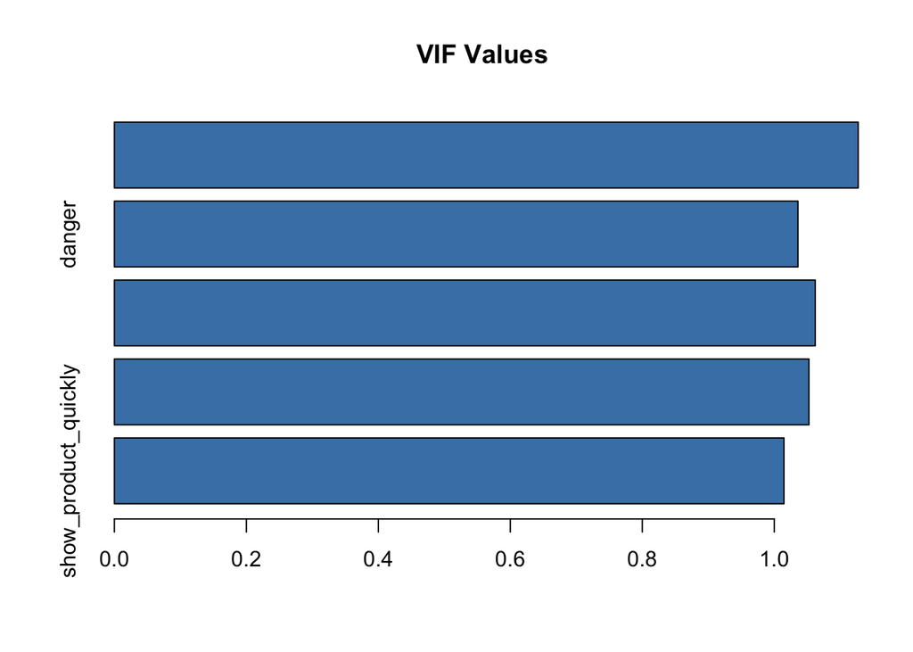

```r
vif_values <- car::vif(model2)         #create vector of VIF values

barplot(vif_values, main = "VIF Values", horiz = TRUE, col = "steelblue") #create horizontal bar chart to display each VIF value

abline(v = 5, lwd = 3, lty = 2)    #add vertical line at 5 as after 5 there is severe correlation
```

Because all our VIF values are less than 10, that means that we don’t have high multicolinearity.

## 5.4 Goodness-of-fit Test

```r
# Deviance residuals test
cat("Deviance residuals test p-value:",
1-pchisq(model2$deviance, model2$df.residual), end="\n")
```

```
Deviance residuals test p-value: 0.3234444
```

```r
# Pearson residuals test
pResid <- resid(model2, type = "pearson")
cat("Pearson residuals test p-value:",
1-pchisq(sum(pResid^2), model1$df.residual))
```

```
Pearson residuals test p-value: 0.6031194
```

The p-values from both goodness of fit tests are very large, suggesting that we fail to reject the null hypothesis that the model is a good fit.

## 5.5 Dispersion

```r
# Calculate dispersion parameter
cat("Overdispersion value:",
model2$deviance/model2$df.res)
```

```
Overdispersion value: 1.045617
```

## 5.6 Goodness of Fit graph checks

```r
# Store the deviance residuals
res = resid(model2,type="deviance")

par(mfrow=c(1,2))
qqPlot(res, ylab="Deviance residuals")
```

```
199 150
103  74
```

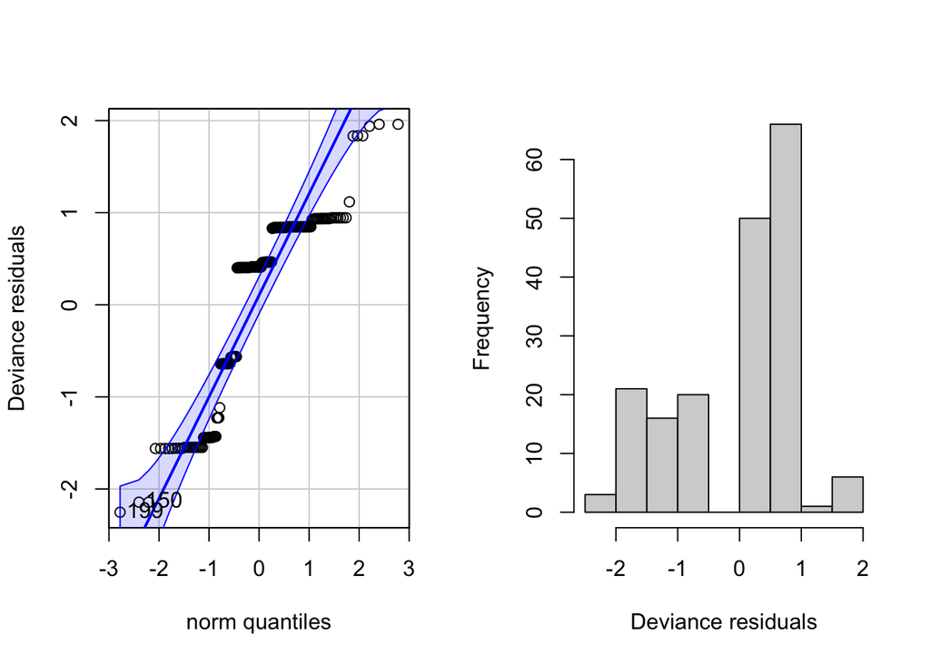

```r
hist(res,10,xlab="Deviance residuals", main="")
```

## 5.7 Cook’s distance for outliers

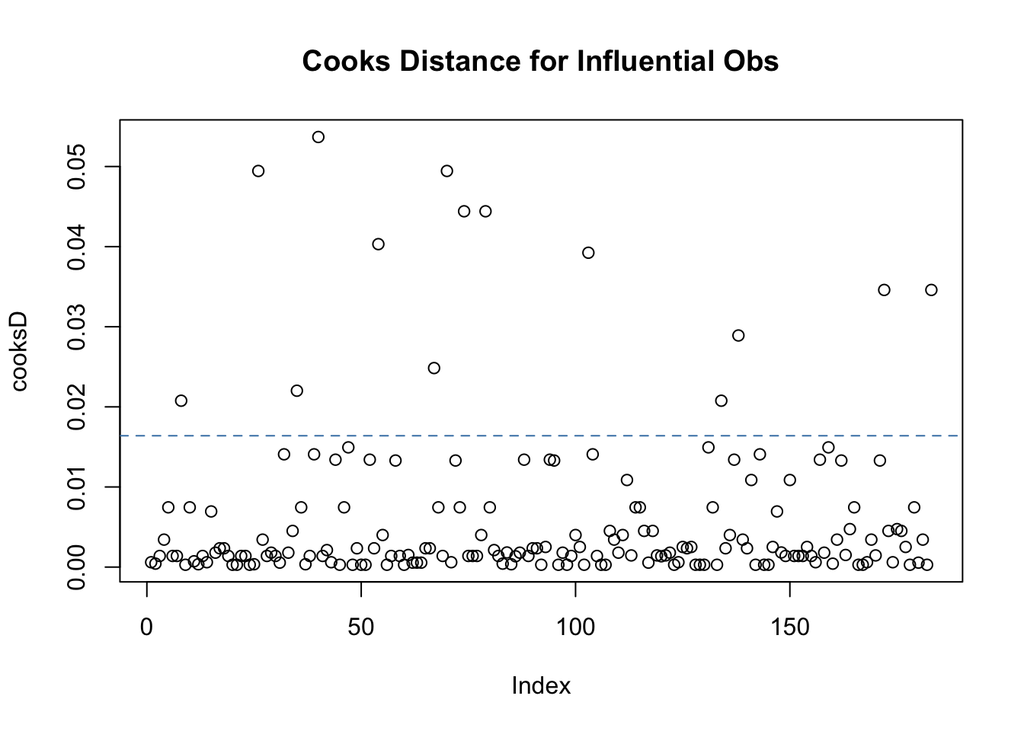

```r
#find Cook's distance for each observation in the dataset
cooksD <- cooks.distance(model2)

# Plot Cook's Distance with a horizontal line at 4/n to see which observations
#exceed this thresdhold
n <- nrow(data)
plot(cooksD, main = "Cooks Distance for Influential Obs")
abline(h = 4/n, lty = 2, col = "steelblue") # add cutoff line
```

Cook’s distance helps us see which and how many outliers we have. As you can see we have a few datapoints that pass our threshold to be considered normal. This was just to explore our data more. If we wanted, we can filter out these points and go through the models again to see if our accuracy improves. However since we don’t have as many datapoints as I would like ideally, we will choose to keep these datapoints and keep the model untouched.

## 5.8 Accuracy of the full model

```r
pred = predict(model2, newdata=datatest, type="response")
pred = ifelse(pred >= .5, TRUE, FALSE)
accuracy <- table(pred, datatest[,"funny"])
cat("The percent accuracy of this model is:",
sum(diag(accuracy))/sum(accuracy))
```

```
The percent accuracy of this model is: 0.7377049
```

We have a very good accuracy percentage for this model, and it lies in line with the goodness-of-fit results we found earlier.

# 6 Variable Selection

With variable selection, we can focus on a model which only has the variables that are imporant in predicting our response variable. To do this, we will take the full model, as well as the minimum model, and perform stepwise regression. Stepwise regression will automatically filter out the variables for us.

## 6.1 Backwards stepwise

```r
model3=glm(funny~., family = binomial, data = data)

set.seed(100)

min.model <-  glm(funny~ 1, family = binomial, data = data)

# Perform stepwise regression
model4 <- step(model3, scope = list(lower = min.model, upper = model3),
                  direction = "backward", trace = FALSE)
summary(model4)
```

```
Call:
glm(formula = funny ~ patriotic + danger, family = binomial,
    data = data)

Deviance Residuals:
    Min       1Q   Median       3Q      Max
-2.1768  -0.7482   0.4432   0.8489   1.6793

Coefficients:
              Estimate Std. Error z value Pr(>|z|)
(Intercept)     0.8351     0.1848   4.518 6.25e-06 ***
patrioticTRUE  -1.9652     0.3944  -4.983 6.25e-07 ***
dangerTRUE      1.4359     0.4068   3.530 0.000416 ***
---
Signif. codes:  0 '***' 0.001 '**' 0.01 '*' 0.05 '.' 0.1 ' ' 1

(Dispersion parameter for binomial family taken to be 1)

    Null deviance: 302.69  on 243  degrees of freedom
Residual deviance: 254.25  on 241  degrees of freedom
AIC: 260.25

Number of Fisher Scoring iterations: 4
```

As we see, the new model has reduced variables which is good, because the fewer variables we have, the less complex our model is. This also falls in line with our findings from before where the strongest variables and significant variables were patriotic and danger. Next we can go ahead and test the accuracy of this model.

## 6.2 Accuracy of backwards stepwise

```r
pred = predict(model4, newdata=datatest, type="response")
pred = ifelse(pred >= .5, TRUE, FALSE)
accuracy <- table(pred, datatest[,"funny"])
cat("The percent accuracy of this model is:",
sum(diag(accuracy))/sum(accuracy))
```

```
The percent accuracy of this model is: 0.7213115
```

## 6.3 Forward stepwise

```r
set.seed(100)

min.model <-  glm(funny~ 1, family = binomial, data = datatrain)

# Perform stepwise regression
model5 <- step(min.model, scope = list(lower = min.model, upper = model3),
                  direction = "forward", trace = FALSE)
summary(model5)
```

```
Call:
glm(formula = funny ~ patriotic + danger, family = binomial,
    data = datatrain)

Deviance Residuals:
    Min       1Q   Median       3Q      Max
-2.2171  -0.6137   0.4231   0.8746   1.8775

Coefficients:
              Estimate Std. Error z value Pr(>|z|)
(Intercept)     0.7639     0.2121   3.601 0.000317 ***
patrioticTRUE  -2.3381     0.4930  -4.742 2.11e-06 ***
dangerTRUE      1.6044     0.4761   3.370 0.000752 ***
---
Signif. codes:  0 '***' 0.001 '**' 0.01 '*' 0.05 '.' 0.1 ' ' 1

(Dispersion parameter for binomial family taken to be 1)

    Null deviance: 231.55  on 182  degrees of freedom
Residual deviance: 185.54  on 180  degrees of freedom
AIC: 191.54

Number of Fisher Scoring iterations: 4
```

## 6.4 Accuracy of forward stepwise

```r
pred = predict(model5, newdata=datatest, type="response")
pred = ifelse(pred >= .5, TRUE, FALSE)
accuracy <- table(pred, datatest[,"funny"])
cat("The percent accuracy of this model is:",
sum(diag(accuracy))/sum(accuracy))
```

```
The percent accuracy of this model is: 0.7213115
```

We see that applying the forward stepwise regression also gave us the same model as before, which in turn gave us the same accuracy. This is not necessarily a bad thing. In fact having the same two variables chosen in two different variable selection process is a good indicator that these variables are important. The same results can be explained by the fact that our dataset isn’t very large to begin with, as its only seen with larger datasets that the variables in forward and backwars stepwise start to differ.

# 7 Conclusion

We evaluated a dataset that contained many variables to see if we can predict if an ad is going to be funny or not. We started off with testing each variable individually to understand the coefficients and how much of an impact it will have on our response variable. We then looked at the full model to help us explain what happens if we don’t do any ML, and just threw everything at the wall to see what sticks. The full model had an accuracy of approximately 73% which wasn’t too bad. We also failed to reject the null hypothesis that the model is a good fit, which is a great sign. Lastly we performed two types of variable selection where we reduced our model down to simply two variables.

We saw that the accuracy two hit. Compared to the previous model’s 73%, the newer models only had an accuracy of 72%. This can probably be explained by the random nature of our data. There are many things which we can try to do to increase our accuracy, one being using cook’s distance, which we measured earlier, to remove any outliers we have in our dataset. We can also look for more data to feed into our models (both training and testing purposes) to reduce randomness. Looking at the bigger picture, while our accuracy did go down technically (and that ideally isn’t supposed to be the case with variable selection), we only lost 1% at the expense of reducing the complexity of our model (which is just as important).